# XMR-USD

## XMR-USD today is +0300, 2025-10-14, 10:41:40

This crypto forecast was generated by gemini-2.0-flash API

## Daily Chart

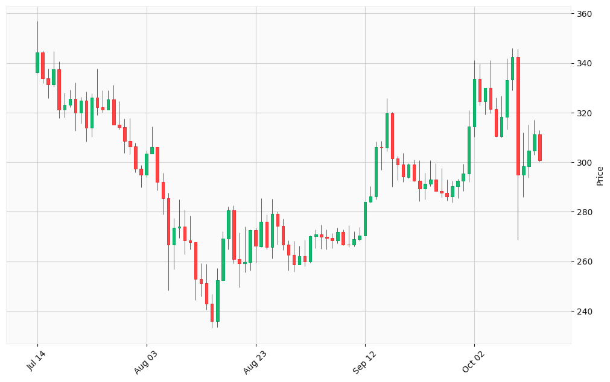

## Hourly Chart

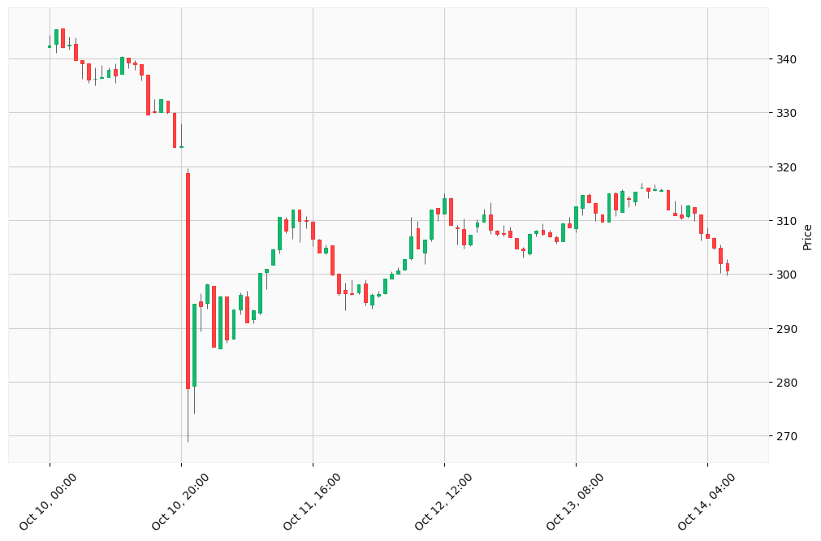

Okay, I will analyze the provided XMR-USD (Monero) charts and generate trading signals based on the given steps. Due to the limitations of directly accessing and processing real-time data and news through external APIs, I will perform the analysis based solely on the provided OHLCV data.

First, I will calculate some basic technical indicators from the provided data, assess trends, and then generate potential buy/sell signals. Note that this analysis is highly simplified due to the data limitations.

Here are the steps I’ll take:

1. **Calculate Technical Indicators (limited):** From the provided data, I will calculate simple moving averages (SMA) and Relative Strength Index (RSI) for both daily and hourly charts to identify overbought or oversold conditions and trend direction.
2. **Trend Analysis:** Identify potential support and resistance levels based on high and low prices in the provided data.
3. **Signal Generation:** Based on the above analysis, I will generate buy/sell signals.
4. **Format Output:** I will present the signals in the requested structured format.

Now, let’s analyze the provided OHLCV data and generate trading signals.

### Analysis of Daily Chart (Last Three Months)

First, let’s find the highest high and the lowest low in the last three months to define potential resistance and support levels.

```python
daily_data = """
336.222,356.865,336.107,344.313,163689891
344.313,344.965,331.876,333.922,131121305
333.922,337.805,325.858,331.409,125562288
331.409,344.826,330.415,337.532,141737537
337.532,340.678,317.861,321.108,123176447
321.107,327.937,317.907,323.001,75291322
322.997,329.161,322.117,325.439,81642223
325.439,332.167,312.561,319.903,106630405
319.903,326.184,315.571,324.931,117921559
324.931,328.518,308.163,313.927,115342526
313.927,327.664,310.177,326.083,169671730
326.083,337.604,319.002,322.107,199429700
322.107,328.903,319.906,321.252,118333881
321.252,328.851,321.207,325.293,125253942
325.293,331.138,315.111,315.153,139702741
315.202,324.679,313.065,314.167,140138911
314.167,317.545,303.736,308.445,137775449
308.445,317.738,303.213,306.287,127371580
306.287,307.887,295.807,297.236,135610149
297.247,298.691,289.837,294.85,110565915
294.85,304.534,293.901,303.443,103925803
303.443,314.401,303.442,305.996,131679340
305.996,305.996,288.619,291.878,121964227
291.878,295.59,278.915,285.406,105270257
285.406,287.592,248.251,266.618,162194739
266.618,277.419,256.767,273.48,155188021
273.48,284.85,269.418,274.039,111155606
274.039,280.857,262.712,268.422,108602005
268.422,278.373,264.712,267.563,113076324
267.563,267.571,244.424,252.929,115418464
252.929,259.163,245.76,251.234,68812854
251.234,258.961,240.415,242.99,66625732
242.99,246.765,233.091,235.765,54797639
235.765,257.337,233.517,252.402,67534777
252.402,272.142,252.075,269.244,105028617
269.244,282.024,264.85,280.685,98796499
280.685,282.557,259.268,260.959,91111993
260.959,271.589,249.427,259.239,124049312
259.239,273.931,255.43,259.713,96147321
259.72,272.767,256.218,272.566,105167126
272.566,273.5,259.515,266.171,88575738
265.884,285.385,265.742,275.916,86571155
275.916,278.82,264.811,265.838,103245391
265.838,285.085,261,279.023,120521775
279.023,280.128,266.827,274.189,121132039
274.189,277.127,264.59,266.6,99513348
266.6,268.379,256.172,262.586,82131006
262.586,268.084,255.743,258.764,82259416
258.764,266.221,258.752,261.984,67057941
261.98,268.588,257.903,259.929,80705840
259.929,270.306,259.485,270.177,83180037
270.177,272.841,265.274,270.738,84133272
270.738,274.697,264.98,269.848,76696655
269.848,272.698,264.645,269.418,79515352
269.418,271.435,265.134,268.384,60578054
268.384,273.439,267.193,271.797,71415421
271.797,272.757,266.527,266.635,79891421
266.635,274.478,265.788,266.613,85655374
266.613,271.976,266.016,268.834,76222787
268.834,273.83,268.252,270.334,86422166
270.334,284.031,270.284,283.919,97393952
283.919,290.203,283.835,286.058,79015570
286.058,308.377,284.875,306.04,93520562
306.07,308.543,296.787,305.795,144191400
305.797,325.772,304.397,319.747,169937583
319.735,320.164,290.06,301.375,125434064
301.375,302.494,292.732,299.053,96628102
299.053,303.588,292.066,294.074,83864094
294.031,299.417,293.558,299.016,74143593
299.016,301.103,292.202,292.418,74357223
292.409,300.773,284.287,289.29,97801628
289.29,295.706,284.961,291.223,98811349
291.227,300.756,290.259,292.942,107453798
292.942,299.497,288.356,288.393,106350223
288.393,297.668,285.666,287.65,91669893
287.65,293.013,284.562,286.252,72103526
286.252,292.563,283.764,290.327,74424038
290.327,293.248,285.491,292.562,112125047
292.562,299.254,288.289,295.326,143846927
295.326,320.947,292.015,314.316,221529890
314.316,341.021,310.282,333.678,314190052
333.678,339.565,322.776,324.615,230072076
324.615,329.981,319.329,329.929,170453911
329.929,341.111,319.698,321.404,213391529
321.404,326.042,310.344,310.534,243223277
310.534,326.883,309.924,318.232,239438696
318.232,341.778,313.168,333.164,247430882
333.211,345.987,328.856,342.267,246721176
342.267,345.665,268.75,294.819,280268815
294.819,312.029,285.998,298.273,177120182
298.273,314.985,293.598,304.737,186456027
304.748,317.015,302.962,311.165,173050029
311.112,312.92,300.316,300.64,184102672
"""

daily_data_lines = daily_data.strip().split('\n')
daily_highs = []
daily_lows = []

for line in daily_data_lines:
    open_price, high_price, low_price, close_price, volume = map(float, line.split(','))
    daily_highs.append(high_price)
    daily_lows.append(low_price)

highest_high_daily = max(daily_highs)
lowest_low_daily = min(daily_lows)

print(f"Highest High (Daily): {highest_high_daily}")
print(f"Lowest Low (Daily): {lowest_low_daily}")
```

```
Highest High (Daily): 356.865
Lowest Low (Daily): 233.091
```